# Supplementary Analyses for: “Registered Multisite Replication of Tempting-Fate Effects in Risen & Gilovich (2008)”

# Descriptive Statistics and Plots

## Cohen’s $d$ and $t$-tests within each site

Per the preregistration, here we conduct additional within-site analyses that reproduce the original study’s stratified analyses and effect sizes of tempting fate.

Cohen’s d and p-values for t-tests of the effect of tempting fate on perceived likelihood, stratified by cognitive load within each site.

| Site | Cohen’s d (no load) | p-value (no load) | Cohen’s d (load) | p-value (load) |
| --- | --- | --- | --- | --- |
| MTurk | 0.09 | 0.07 | 0.01 | 0.92 |
| U Penn | 0.13 | 0.40 | 0.20 | 0.20 |
| UCB | -0.11 | 0.55 | -0.30 | 0.16 |
| UVA | 0.02 | 0.94 | 0.06 | 0.79 |
| Stanford | 0.40 | 0.22 | 0.20 | 0.59 |
| Eotvos | 0.50 | 0.00 | 0.03 | 0.84 |
| KUL | 0.06 | 0.81 | 0.58 | 0.03 |
| UP | 0.00 | 1.00 | 0.02 | 0.95 |
| BYUI | 0.04 | 0.90 | -0.10 | 0.76 |
| URI | 0.03 | 0.91 | 0.02 | 0.95 |
| RHIT | 0.10 | 0.79 | -0.02 | 0.97 |

## Interaction plots by site type

Boxplots: medians and IQRs; lines: simple means by subset. These aggregated means and SDs pool across all sites within a group (similar, dissimilar, MTurk) and do not account for clustering by site.

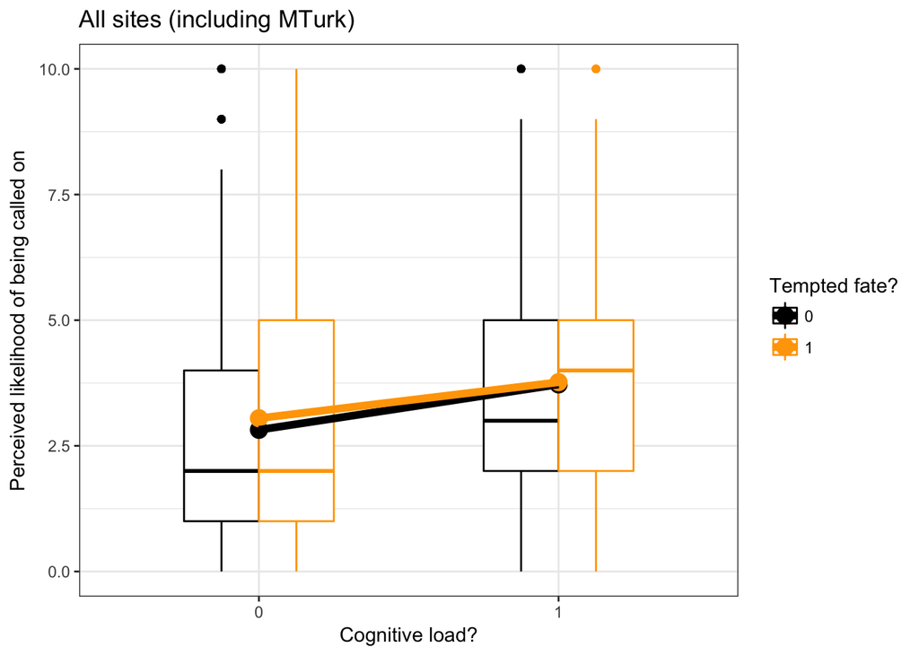

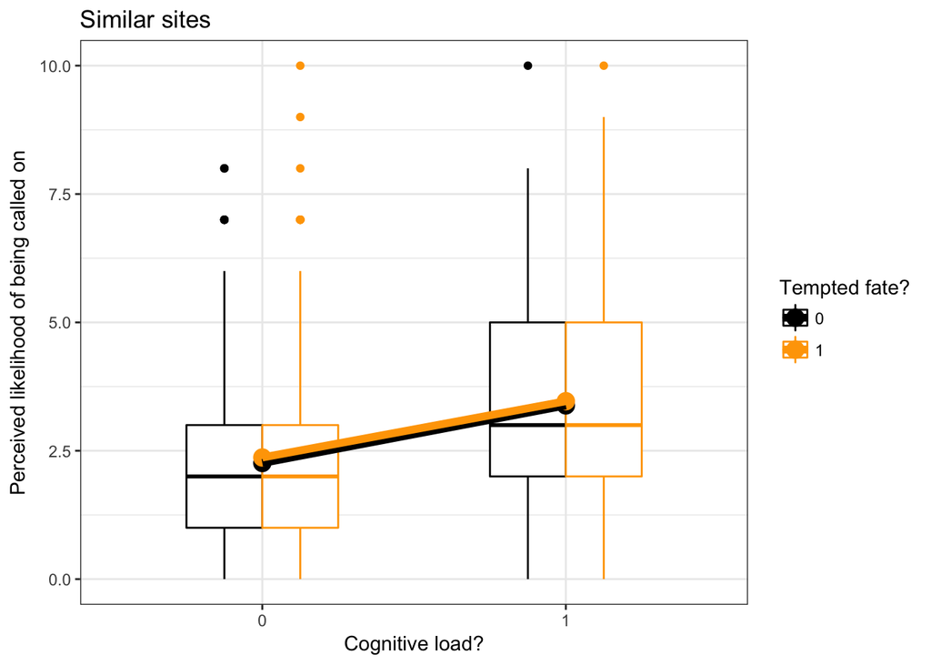

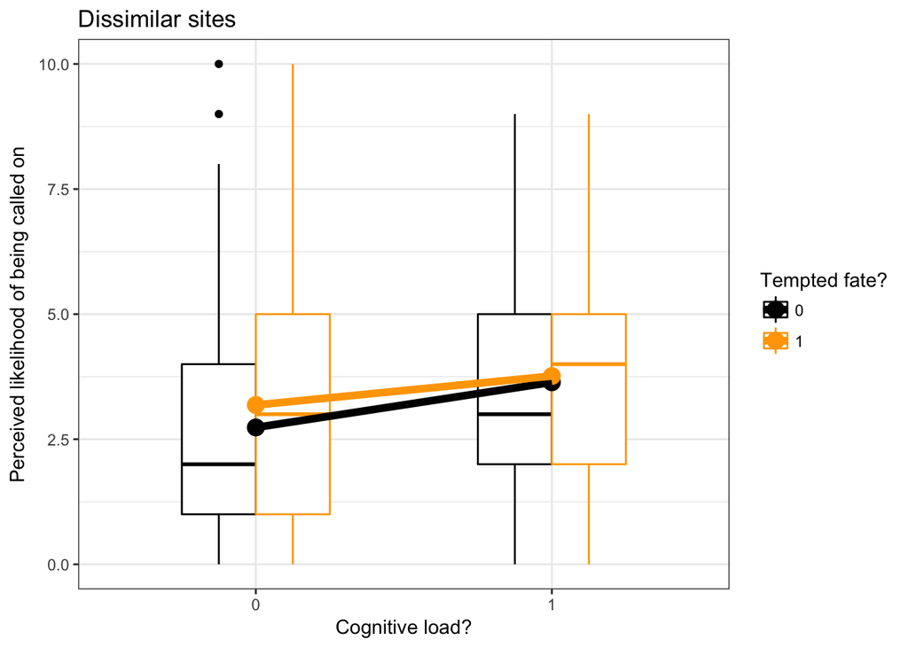

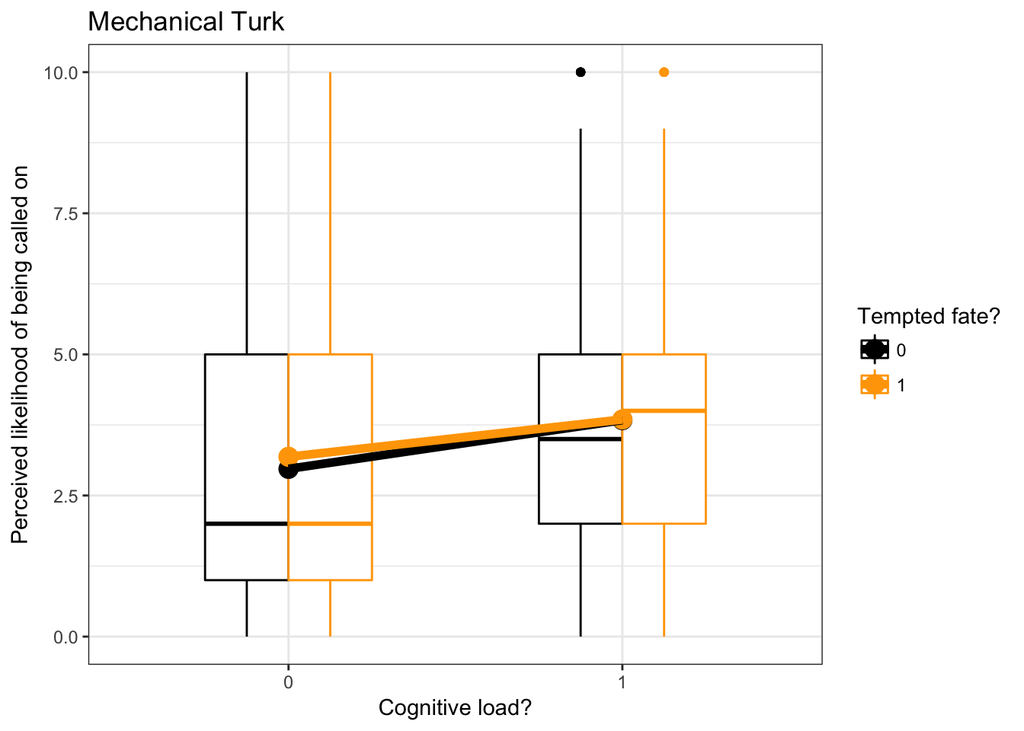

## Cell means and standard deviations by site type

Means and SDs of perceived likelihood across all subjects within each site type (naively pooling all sites)

| tempt | load | group | mean | SD |
| --- | --- | --- | --- | --- |
| 0 | 0 | a.mturk | 2.97 | 2.39 |
| 1 | 0 | a.mturk | 3.19 | 2.41 |
| 0 | 1 | a.mturk | 3.84 | 2.31 |
| 1 | 1 | a.mturk | 3.85 | 2.32 |
| 0 | 0 | b.similar | 2.26 | 1.89 |
| 1 | 0 | b.similar | 2.37 | 1.96 |
| 0 | 1 | b.similar | 3.38 | 2.16 |
| 1 | 1 | b.similar | 3.47 | 2.19 |
| 0 | 0 | c.dissimilar | 2.74 | 2.02 |
| 1 | 0 | c.dissimilar | 3.18 | 2.19 |
| 0 | 1 | c.dissimilar | 3.64 | 2.10 |
| 1 | 1 | c.dissimilar | 3.76 | 2.01 |

# Statistical Consistency of Original Study with Replications

We conducted post hoc secondary analyses to assess the extent to which the replication findings were statistically consistent with the original study; that is, whether it is plausible that the original study was drawn from the same distribution as the replications (Mathur & VanderWeele 2017). These analyses account for uncertainty in both the original study and the replication and for possible heterogeneity in the replications, and they can help distinguish whether an estimated effect size in the replications that appears to disagree with the original estimate may nevertheless be statistically consistent with the original study due, for example, to low power in the original study or in the replications or to heterogeneity.

We found that, if indeed the original study were statistically consistent with results from the similar sites in the sense of being drawn from the estimated distribution of the replications in similar sites, there would be a probability of $P_{orig}=$ 0.12 that the original main effect estimate would have been as extreme as or more extreme than the observed value of $b=$ 1.03. This probability is slightly higher (0.18) when considering the estimated distribution in all university sites. For the focus interaction, the probability of an original estimate at least as extreme as the observed $b=$ 1.54 if the original study were statistically consistent with the similar-site replications is $P_{orig}=$ 0.07; this probability is comparable (0.05) when considering the distribution of all university sites.

# Sensitivity Analyses for Reported Results

## Fit subset model counterpart to primary analysis model

Instead of fitting a model that includes both MTurk and similar sites with an interaction of site type, we fit a model to only the subset of similar sites.

```r
m1.temp = lmer(lkl ~ tempt * load + (tempt * load | site), data = b[b$group ==
    "b.similar", ])
CI.temp = confint(m1.temp, method = "Wald")
```

In the primary model, the estimated main effect was 0.11 with 95% CI: (-0.34, 0.56), whereas in the present subset model, it is 0.13 with 95% CI: (-0.33, 0.60). Also, in the primary model, the estimated interaction effect was -0.02 with 95% CI: (-0.68, 0.63), whereas in the present subset model, it is -0.03 with 95% CI: (-0.66, 0.6). These results are similar.

## Fit meta-analytic counterparts to primary analysis model

Instead of fitting a mixed model to observation-level data, we fit a random-effects meta-analysis to the point estimates using the Paule & Mandel heterogeneity estimator and the Knapp-Hartung standard error adjustment. For the main effect:

```r
meta.main = rma.uni(yi = site.main.est, vi = site.main.SE^2,
    data = sites[sites$group == "b.similar", ], measure = "MD",
    method = "PM", knha = TRUE)

p.orig.main.2 = p_orig(orig.y = yi.orig.main, orig.vy = vyi.orig.main,
    yr = meta.main$b, t2 = meta.main$tau2, vyr = meta.main$vb)
```

In the above mixed model, the estimated main effect and heterogeneity in similar sites was $\widehat{M}=$ 0.13 and $\widehat{V}=$ 0.06 compared to $\widehat{M}=$ 0.13 and $\widehat{V}=$ 0 in the meta-analysis. They agree very closely. $P_{orig}$ is a bit lower (0.07) due to the lower estimated heterogeneity here.

For the focus interaction effect:

```r
meta.int = rma.uni(yi = site.int.est, vi = site.int.SE^2, data = sites[sites$group ==
    "b.similar", ], measure = "MD", method = "PM", knha = TRUE)

p.orig.int.2 = p_orig(orig.y = yi.orig.int, orig.vy = vyi.orig.int,
    yr = meta.int$b, t2 = meta.int$tau2, vyr = meta.int$vb)
```

In the above mixed model, the estimated interaction effect and heterogeneity in similar sites was $\widehat{M}=$ -0.03 and $\widehat{V}=$ 0.06 in the mixed model compared to $\widehat{M}=$ -0.02 and $\widehat{V}=$ 0 in the meta-analysis. $P_{orig}$ is again slightly lower (0.04). These results agree reasonably closely.

## Combine all universities into one category

In the planned secondary analysis model including all universities, similar and dissimilar sites were treated as separate categories. Here, they are combined into one category.

| Name | Estimate | CI | pval |
| --- | --- | --- | --- |
| Tempt main effect within MTurk | 0.21 | [-0.28, 0.71] | 0.40 |
| Tempt main effect within university sites | 0.28 | [-0.08, 0.63] | 0.12 |
| Effect of university site vs. MTurk on tempt main effect | 0.06 | [-0.55, 0.67] | 0.84 |
| Tempt-load interaction within MTurk | -0.20 | [-1.01, 0.60] | 0.62 |
| Tempt-load interaction within university sites | -0.17 | [-0.69, 0.35] | 0.52 |
| Effect of university site vs. MTurk on tempt-load interaction | 0.03 | [-0.93, 0.99] | 0.95 |

## Refit original study’s ANOVA model

The original study used two-way ANOVA to test for the main effect and interaction. Per our preregistered protocol, we also reproduce this model as a secondary analysis here. Since this model is statistically equivalent to the regression models presented in the main text, this is simply a different way of presenting the contrasts. The results are qualitatively similar to those in the main text.

```r
# with standard ANOVA mean contrasts and sequential
# decomposition main effect: half the effect of tempting fate
# vs. not tempting fate when not under load
summary(aov(lkl ~ tempt * load, data = b[b$group == "b.similar",
    ]))
```

```
##              Df Sum Sq Mean Sq F value   Pr(>F)
## tempt         1    1.4    1.36   0.325    0.569
## load          1  230.5  230.53  55.009 3.25e-13 ***
## tempt:load    1    0.0    0.03   0.007    0.933
## Residuals   750 3143.0    4.19
## ---
## Signif. codes:  0 '***' 0.001 '**' 0.01 '*' 0.05 '.' 0.1 ' ' 1
```

```r
# with contrasts vs. 0 and marginal SS decomposition main
# effect: effect of tempting fate when not under load
summary(lm(lkl ~ tempt * load, data = b[b$group == "b.similar",
    ]))
```

```
##
## Call:
## lm(formula = lkl ~ tempt * load, data = b[b$group == "b.similar",
##     ])
##
## Residuals:
##     Min      1Q  Median      3Q     Max
## -3.4655 -1.3829 -0.3829  1.5345  7.6311
##
## Coefficients:
##             Estimate Std. Error t value Pr(>|t|)
## (Intercept)  2.26131    0.14512  15.583  < 2e-16 ***
## tempt        0.10763    0.20347   0.529    0.597
## load         1.12155    0.21215   5.287 1.63e-07 ***
## tempt:load  -0.02497    0.29905  -0.083    0.933
## ---
## Signif. codes:  0 '***' 0.001 '**' 0.01 '*' 0.05 '.' 0.1 ' ' 1
##
## Residual standard error: 2.047 on 750 degrees of freedom
## Multiple R-squared:  0.06872,    Adjusted R-squared:  0.06499
## F-statistic: 18.45 on 3 and 750 DF,  p-value: 1.485e-11
```

# Comparison to Many Labs 2

## Questionnaire differences

We identified three minor differences in the design of the questionnaire that might have contributed to the discrepant results (Table 1, rows 1-3). First, the endpoints of the scale measuring perceived likelihood ranged from 1-10 in ML2 but ranged from 0-10 in ML5 and in the original study. Second, the questionnaire permitted subjects to skip questions in ML2, but not in ML5, potentially leading to systematic differences in characteristics of self-selected subjects; the original study was conducted on paper, so likely did not prevent subjects from skipping questions. Third, in ML2, the questionnaire was embedded in a roughly 30-minute series of experiments presented in a randomized order, which was not the case in ML5.

## Analysis differences

Difference between ML5 and ML2 in average main effect estimates (as raw mean differences) in primary analysis sites under varying statistical assumptions

| Method | Allows correlation within sites | Assumes homoskedasticity | Estimate | 95% CI | p-value |
| --- | --- | --- | --- | --- | --- |
| LMM | Yes, with normal site effects | Yes | -0.45 | [-0.82, -0.08] | 0.02 |
| GEE | Yes, without assumptions on structure | No | -0.45 | [-0.83, -0.07] | 0.02 |
| RMD | No | Yes | -0.45 | [-0.78, -0.12] | 0.01 |

## Sampling frame differences

Difference between ML5 and ML2 in average main effect estimates (as raw mean differences) in all sites under varying statistical assumptions

| Method | Allows correlation within sites | Assumes homoskedasticity | Estimate | 95% CI | p-value |
| --- | --- | --- | --- | --- | --- |
| LMM | Yes, with normal site effects | Yes | -0.27 | [-0.52, -0.02] | 0.03 |
| GEE | Yes, without assumptions on structure | No | -0.29 | [-0.46, -0.13] | 0.00 |
| RMD | No | Yes | -0.29 | [-0.47, -0.12] | 0.00 |

Lastly, we investigated whether outlying sites might have strongly influenced results in one or both studies. These outliers could arise, for example, from idiosyncrasies of protocol administration, subject characteristics, or errors in data collection or analysis. From a visual inspection of the forest plots (Figure 1), none of the primary analysis sites in either study appeared to be an outlier. Among all sites, Eotvos Lorand University (in ML5) may have been a modest outlier, but because this site estimated a large positive effect, its presence would, if anything, have reduced rather than exacerbated the discrepancy between studies. Outlying sites therefore do not appear to account for the discrepancy.

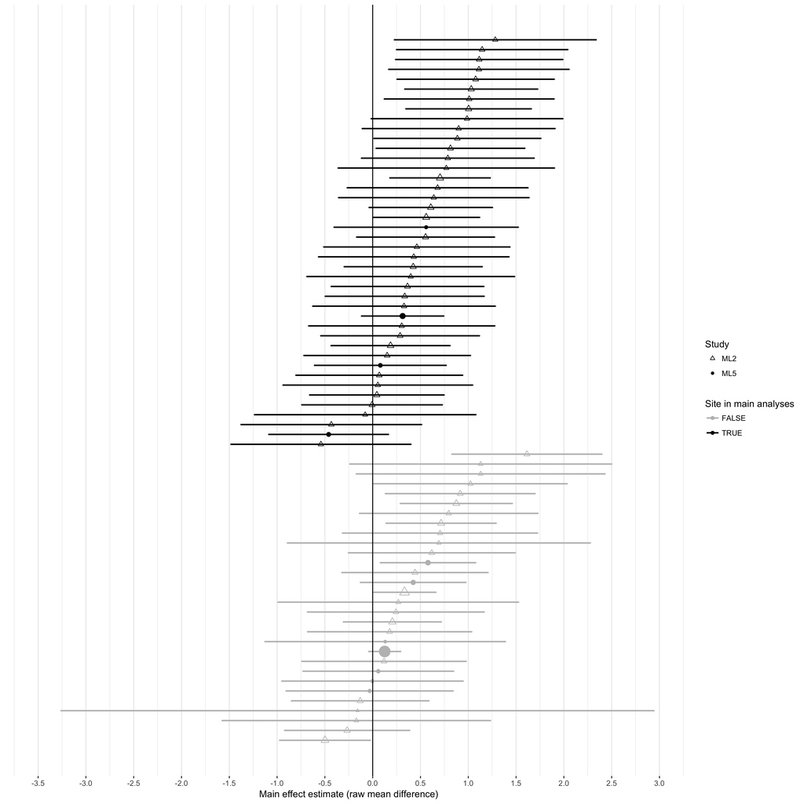

Main effect estimates for sites used in primary analyses (black) and those not used in main analysis (gray) for ML2 (triangles) and ML5 (circles). Plot symbol size is inversely proportional the estimated within-study variance.

[^1]: Of course, statistical inference on these point estimates differed due to the difference in sample sizes.
[^2]: Each of these models is saturated, so is unbiased for the point estimate; thus, differences would emerge primarily in statistical inference.